# matplotlib

## 환경설정

```python
%matplotlib inline
from matplotlib import pyplot as plt
```

### 폰트 설정

#### 폰트 크기 설정

```python
plt.rcParams['font.size'] = 12 # 기본 폰트 크기 설정
plt.rcParams['axes.labelsize'] = 10 # x,y 레이블 폰트 크기
plt.rcParams['axes.titlesize'] = 10 # 축 제목 글꼴 크기
plt.rcParams['xtick.labelsize'] = 6 # x축 tick 레이블의 글꼴 크기
plt.rcParams['ytick.labelsize'] = 6 # y축 tick 레이블의 글꼴 크기
plt.rcParams['legend.fontsize'] = 10 # 범례 글꼴 크기
```

#### 폰트 변경 (한국어 깨짐 방지)

```python
import matplotlib.font_manager as fonm
font_list = [font.name for font in fonm.fontManager.ttflist] # 폰트 목록 확인
plt.rcParams['font.family'] = 'Malgun Gothic'
```

#### 마이너스 깨짐 방지

```python
import matplotlib
matplotlib.rcParams['axes.unicode_minus'] = False
```

### 그래프 크기 설정

```python
import matplotlib.pyplot as plt
plt.rcParams["figure.figsize"] = (20,10)
```

## 주요 함수

### 선 그래프: plt.plot

matplotlib.pyplot.plot(*args, scalex=True, scaley=True, data=None, **kwargs)

- plot(x, y)
- color, linestyle, linewidth, markersize

```python
# 옵션 확인할 때 사용

import matplotlib
#help(matplotlib.lines.Line2D.__init__)
```

### 산점도: plt.scatter

matplotlib.pyplot.scatter

- x, y: float or array-like, shape (n, ) The data positions.
- s: float or array-like, shape (n, ), optional
- c: array-like or list of colors or color, optional The marker colors. Possible values:
- marker: MarkerStyle, default: rcParams["scatter.marker"] (default: 'o') <matplotlib.markers>
- cmap: str or Colormap, default: rcParams["image.cmap"] (default: 'viridis') A Colormap instance or registered colormap name. cmap is only used if c is an array of floats.
- alpha: float, default: None The alpha blending value, between 0 (transparent) and 1 (opaque).

```python
import matplotlib
#help(matplotlib.markers) # 마커종류확인할때 사용
```

### 막대 그래프: plt.bar

matplotlib.pyplot.bar(x, height, width=0.8, bottom=None, align='center')

- x: float or array-like The x coordinates of the bars.
- height: float or array-like The height(s) of the bars.
- width: float or array-like, default: 0.8 The width(s) of the bars.
- bottom: float or array-like, default: 0 The y coordinate(s) of the bars bases.
- align: {'center', 'edge'}, default: 'center'
- color: color or list of color, optional The colors of the bar faces.
- edgecolor: color or list of color, optional The colors of the bar edges.
- linewidth: float or array-like, optional Width of the bar edge(s). If 0, don't draw edges.
- tick_label: str or list of str, optional The tick labels of the bars. Default: None (Use default numeric labels.)

### 히스토그램: plt.hist

matplotlib.pyplot.hist(x, bins=None, range=None, density=False, weights=None, cumulative=False, bottom=None, histtype='bar', align='mid', orientation='vertical', rwidth=None, log=False, color=None, label=None, stacked=False, *, data=None, **kwargs)

- x(n,): array or sequence of (n,) arrays
- bins: int or sequence or str, default: rcParams["hist.bins"] (default: 10)
  - If bins is an integer, it defines the number of equal-width bins in the range.
  - If bins is a sequence, it defines the bin edges, including the left edge of the first bin and the right edge of the last bin; in this case, bins may be unequally spaced. All but the last (righthand-most) bin is half-open.
  - If bins is a string, it is one of the binning strategies supported by numpy.histogram_bin_edges: 'auto', 'fd', 'doane', 'scott', 'stone', 'rice', 'sturges', or 'sqrt'.
- cumulative: bool or -1, default: False
- histtype: {'bar', 'barstacked', 'step', 'stepfilled'}, default: 'bar'

### 박스플롯: plt.boxplot()

matplotlib.pyplot.boxplot(x, notch=None, sym=None, vert=None, whis=None, positions=None, widths=None, patch_artist=None, bootstrap=None, usermedians=None, conf_intervals=None, meanline=None, showmeans=None, showcaps=None, showbox=None, showfliers=None, boxprops=None, labels=None, flierprops=None, medianprops=None, meanprops=None, capprops=None, whiskerprops=None, manage_ticks=True, autorange=False, zorder=None, *, data=None)

## 그래프 공통 옵션

### 색상

```python
# help(matplotlib.colors) # DESCRIPTION 참고
```

### 컬러맵

'viridis', 'plasma', 'inferno', 'magma', 'cividis' 'Greys', 'Purples', 'Blues', 'Greens', 'Oranges', 'Reds', 'YlOrBr', 'YlOrRd', 'OrRd', 'PuRd', 'RdPu', 'BuPu', 'GnBu', 'PuBu', 'YlGnBu', 'PuBuGn', 'BuGn', 'YlGn'

### tick

```python
# help(matplotlib.text.Text) # 옵션 참고
```

- plt.xticks(위치, 라벨)
- plt.yticks(위치, 라벨)

### 서브 플롯

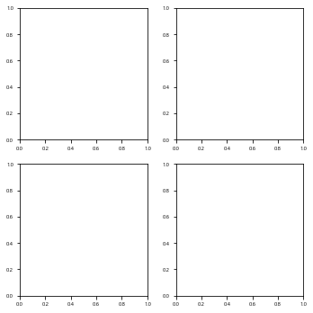

```python
fig = plt.figure(figsize = (5,5))
plt.subplot(2, 2, 1)
plt.subplot(2, 2, 2)
plt.subplot(2, 2, 3)
plt.subplot(2, 2, 4)
fig.tight_layout()
```

# Seaborn

## set: 그래프를 이쁘게!

```python
import seaborn as sns
sns.set()

from matplotlib import pyplot as plt
plt.plot([1,2,3,4], label = "A")
plt.plot([1,3,5,2], label = "B")
plt.legend()
```

[output not shown]

## 히트맵: heatmap

seaborn.heatmap(data, *, vmin=None, vmax=None, cmap=None, center=None, robust=False, annot=None, fmt='.2g', annot_kws=None, linewidths=0, linecolor='white', cbar=True, cbar_kws=None, cbar_ax=None, square=False, xticklabels='auto', yticklabels='auto', mask=None, ax=None, **kwargs)

- data: rectangular dataset 2D dataset that can be coerced into an ndarray. If a Pandas DataFrame is provided, the index/column information will be used to label the columns and rows.
- vmin, vmax: floats, optional Values to anchor the colormap, otherwise they are inferred from the data and other keyword arguments.
- cmap: matplotlib colormap name or object, or list of colors, optional The mapping from data values to color space. If not provided, the default will depend on whether center is set.
- center: float, optional The value at which to center the colormap when plotting divergant data. Using this parameter will change the default cmap if none is specified.
- annot: bool or rectangular dataset, optional If True, write the data value in each cell. If an array-like with the same shape as data, then use this to annotate the heatmap instead of the data. Note that DataFrames will match on position, not index.
- linewidths: float, optional Width of the lines that will divide each cell.
- linecolor: color, optional Color of the lines that will divide each cell.

```python
import numpy as np
import seaborn as sns
uniform_data = np.random.rand(10, 12)
sns.heatmap(uniform_data, cmap = "plasma")
```

[output not shown]

## boxplot

```python
import seaborn as sns
import matplotlib.pyplot as plt

# Initialize the figure with a logarithmic x axis
f, ax = plt.subplots(figsize=(7, 6))
ax.set_xscale("log")

# Load the example planets dataset
planets = sns.load_dataset("planets")

# Plot the orbital period with horizontal boxes
sns.boxplot(x="distance", y="method", data=planets,
            whis=[0, 100], width=.6, palette="vlag")
```

[output not shown]

## pairplot: 상관관계 시각화

```python
penguins = sns.load_dataset("penguins")
sns.pairplot(penguins)
```

[output not shown]